# Supporting Information ‘Wildlife health perceptions and monitoring practices in globally distributed protected areas’

Authors

Affiliation

Diego Montecino-Latorre

Wildlife Conservation Society - Health Program

Mathieu Pruvot

Wildlife Conservation Society - Health Program

Sarah H Olson

Wildlife Conservation Society - Health Program

## 1 Results of non-local responses

### 1.1 Perceptions regarding wildlife health importance in conservation and potential consequences of pathogen transmission among wildlife, domestic animals, and people.

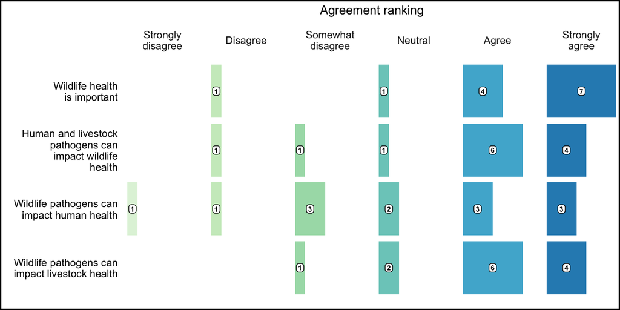

Figure S1. Distribution of the level of agreement among protected area data managers with statements ‘wildlife health is important to achieve the conservation goals of protected area(s) where I work in’ (row 1), ‘human or livestock pathogens can affect wildlife populations inhabiting the protected area(s) where I work in’ (row 2), ‘pathogens carried by wildlife inhabiting the protected area(s) where I work in can affect human health’ (row 3), and ‘pathogens carried by wildlife inhabiting the protected area(s) where I work in can affect livestock health’ (row 4).

### 1.2 Overall frequency of encounters with dead, sick, or injured wildlife in protected areas and their documentation when found during patrols

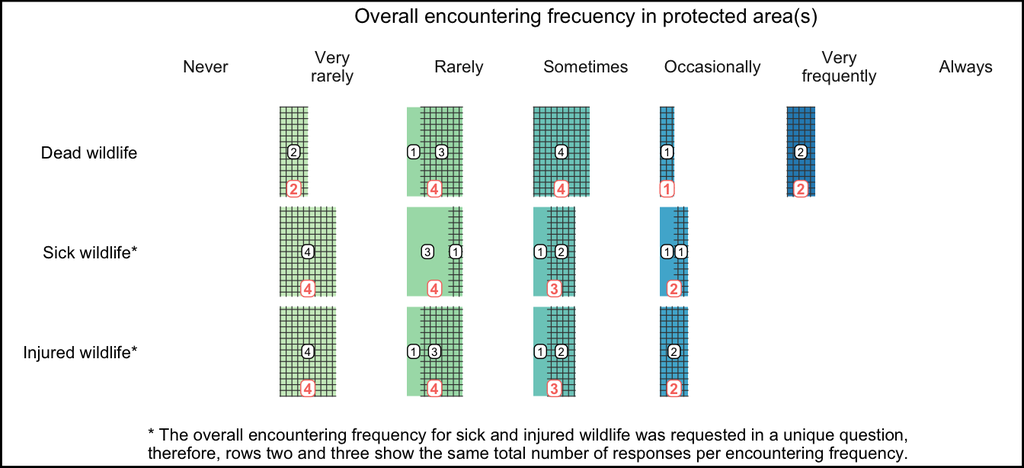

Figure S2. Distribution of protected area data manager responses regarding the encounter of dead and sick or injured wildlife in the protected area(s) where they work. Red numbers indicate the total number of responses per encountering frequency. The dashed area of the polygons represent the responses indicating that dead, sick, and injured wildlife found during ranger patrols are recorded (rows 1 – 3, respectively). Black numbers indicate the total number of responses reporting recording and non-recording of dead, sick, and injured wildlife found during patrols per encountering frequency.

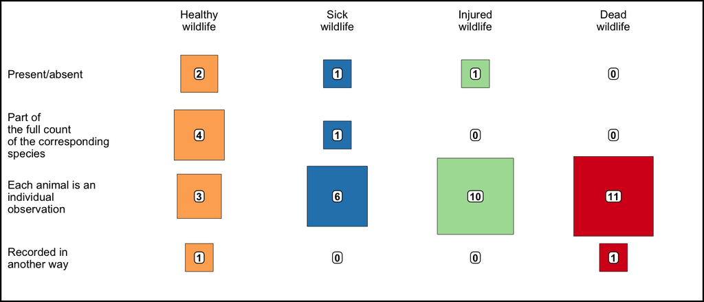

Figure S3. Distribution of methods of documentation to register either sick, injured, or dead wildlife found during ranger patrols reported by protected area data managers.

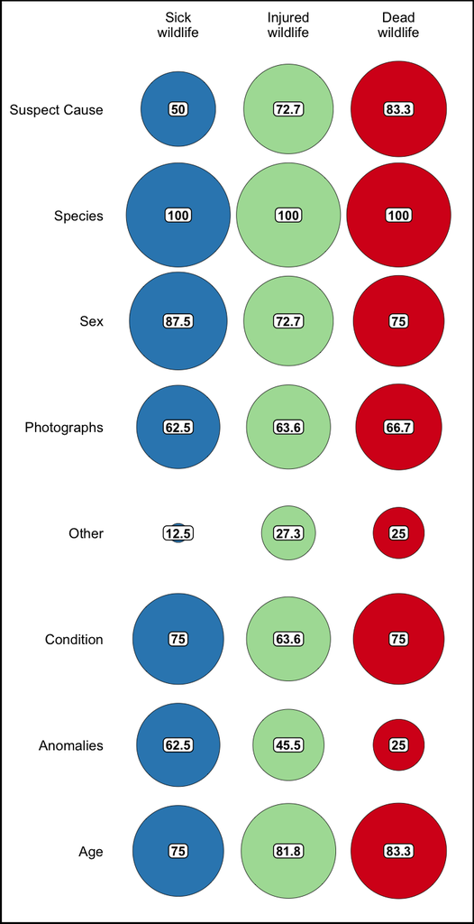

Figure S4. The percentage of protected area data manager responses indicating the documentation of sick, injured, and dead wildlife found during patrols that record specific data items for each wildlife health status. The size of the circles is proportional to the percentages observed.

### 1.3 Presence of domestic animals in protected areas, the documentation of their health status, and the perceived threats of domestic animals to conservation goals

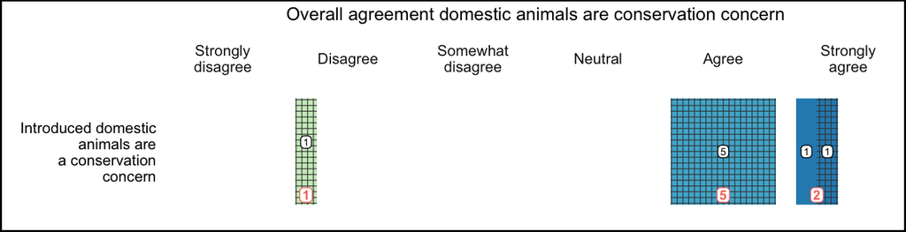

Figure S5. Distribution of the level of agreement among protected area data managers with the statement ‘introduced domestic animals (e.g., dogs, cats, cattle, pigs, cats) are a concern for the conservation goals of the protected areas where I work’. Red numbers indicate the total number of responses per agreement. The dashed area of the polygons represent the responses indicating that domestic animals found during ranger patrols are recorded. Black numbers indicate the total number of responses reporting documentation and non-documentation of domestic animals found during patrols.

### 1.4 Health data storage practices in protected areas

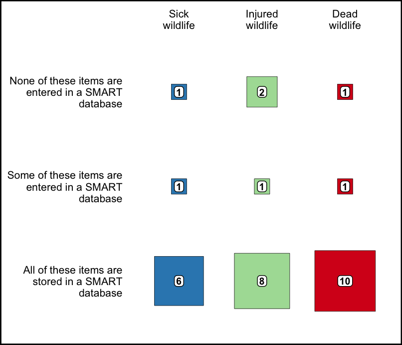

Figure S6. Distribution of protected area data managers reporting the documentation of either sick, injured, or dead wildlife found during ranger patrols across data storage practices with respect to the use of SMART.

## 2 Distribution of responses across their overall agreement with ‘human and livestock pathogens can impact wildlife health’ and ‘introduced domestic animals are a concern for the conservation goals of the protected area’

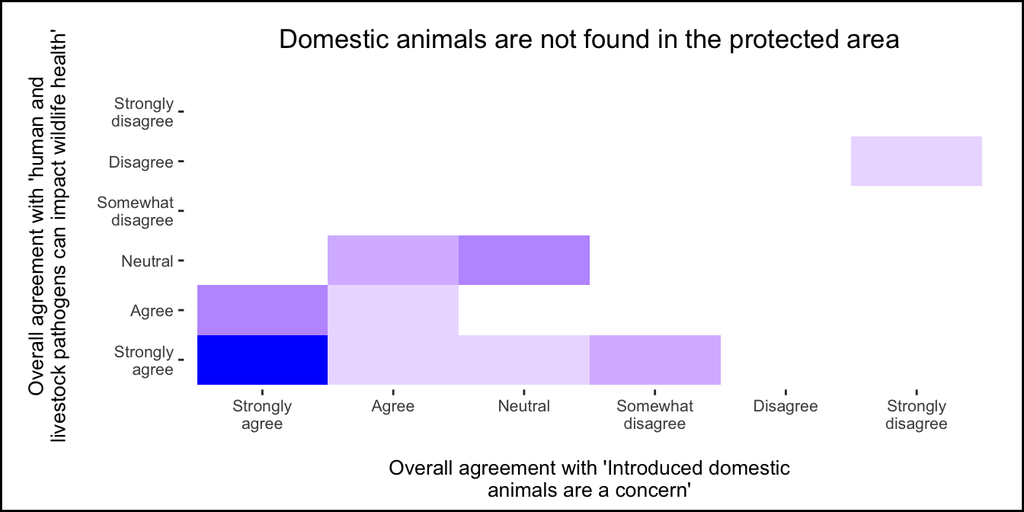

Figure S7. Distribution of protected area data managers responses across their overall agreement with ‘human and livestock pathogens can impact wildlife health’ and ‘introduced domestic animals are a concern for the conservation goals of the protected area’ for those protected area managers that reported the absence of domestic animals in the protected area.

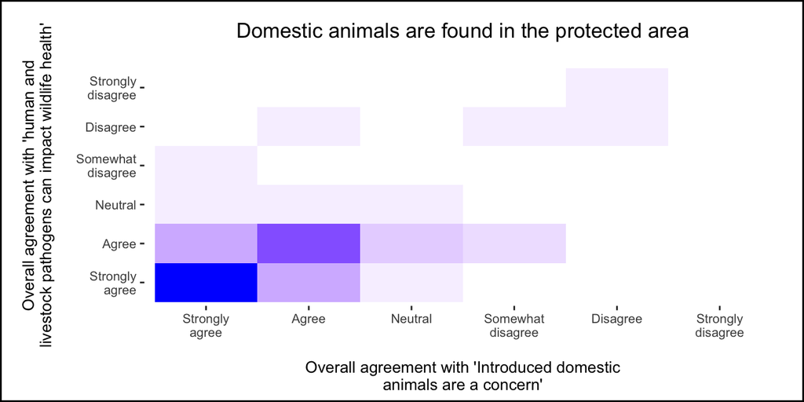

Figure S8. Distribution of protected area data managers responses across their overall agreement with ‘human and livestock pathogens can impact wildlife health’ and ‘introduced domestic animals are a concern for the conservation goals of the protected area’ for those protected area data managers that reported the presence of domestic animals in the protected area.